# Технологический практикум (практикум на ЭВМ)

### Анализ данных с помощью метода огибающих

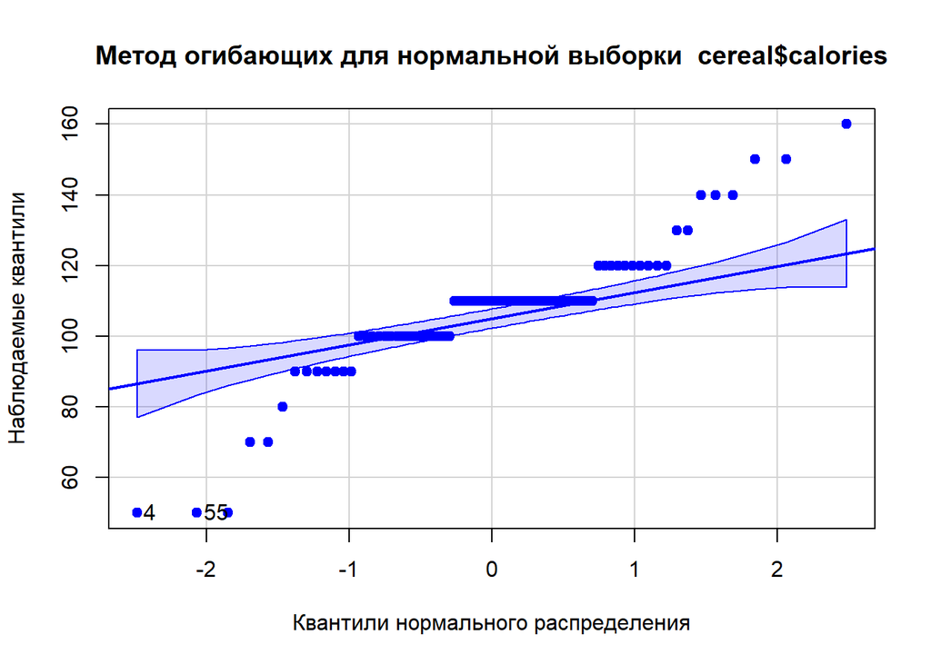

```
## [1]  4 55
```

```r
my_envelope(cereal$calories, data_name="cereal$calories", color="blue")
```

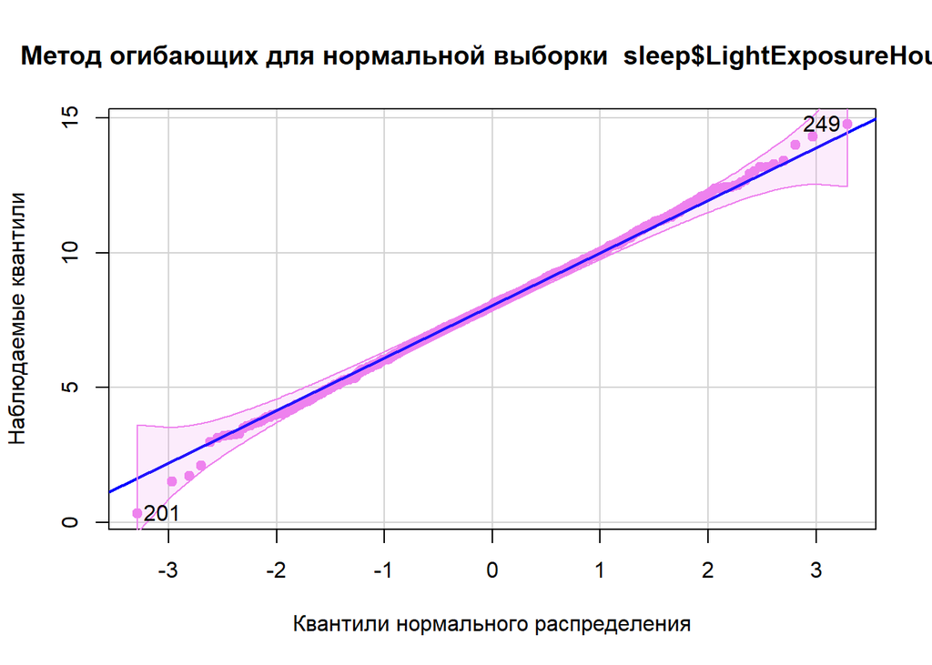

```
## [1] 201 249
```

```r
my_envelope(sleep$LightExposureHours, data_name="sleep$LightExposureHours", color="violet")
```

Исходя из графиков метода огибающих можем сделать вывод, что данные `sleep$LightExposureHours` распределены нормально, в то время как `cereal$calories` нет.

### Стандартные процедуры проверки гипотез о нормальности

#### 1. Критерий Колмогорова-Смирнова

Проведем тест Колмогорова-Смирнова для калорий.

```r
ks.test(cereal$calories, "pnorm")
```

```
## Warning in ks.test.default(cereal$calories, "pnorm"): в тесте согласия
## Колмогорова не должно быть повторяющихся значений
```

```
##
##  Asymptotic one-sample Kolmogorov-Smirnov test
##
## data:  cereal$calories
## D = 1, p-value < 2.2e-16
## alternative hypothesis: two-sided
```

И сразу сталкиваемся с проблемой (warning): для корректного проведения данного теста все значения в выборке должны быть уникальными. Добавим нормальный шум к элементам этой выборки и проведем тест для зашумленных данных.

```r
cereal$calories_noisy <- cereal$calories + rnorm(length(cereal$calories), mean = 0, sd = 1e-6)
ks.test(cereal$calories_noisy, "pnorm", mean = mean(cereal$calories_noisy), sd = sd(cereal$calories_noisy))
```

```
##
##  Exact one-sample Kolmogorov-Smirnov test
##
## data:  cereal$calories_noisy
## D = 0.20269, p-value = 0.002996
## alternative hypothesis: two-sided
```

Данные о калориях не распределены нормально, поскольку тест выдал `p-value < 0.05`. Проведем исследование для LightExposureHours.

```r
ks.test(sleep$LightExposureHours, "pnorm")
```

```
##
##  Asymptotic one-sample Kolmogorov-Smirnov test
##
## data:  sleep$LightExposureHours
## D = 0.99457, p-value < 2.2e-16
## alternative hypothesis: two-sided
```

#### 2. Критерий Шапиро-Уилка

```r
shapiro.test(cereal$calories)
```

```
##
##  Shapiro-Wilk normality test
##
## data:  cereal$calories
## W = 0.89398, p-value = 9.73e-06
```

```r
shapiro.test(sleep$LightExposureHours)
```

```
##
##  Shapiro-Wilk normality test
##
## data:  sleep$LightExposureHours
## W = 0.99921, p-value = 0.9574
```

Данные о калориях не распределены нормально, поскольку тест выдал `p-value < 0.05`. Данные о часах воздействия света в течение дня распределены нормально, поскольку тест выдал `p-value > 0.05`.

#### 3. Критерий Андерсона-Дарлинга

```r
nortest::ad.test(cereal$calories)
```

```
##
##  Anderson-Darling normality test
##
## data:  cereal$calories
## A = 3.3984, p-value = 1.399e-08
```

```r
nortest::ad.test(sleep$LightExposureHours)
```

```
##
##  Anderson-Darling normality test
##
## data:  sleep$LightExposureHours
## A = 0.14421, p-value = 0.9698
```

Данные о калориях не распределены нормально, поскольку тест выдал `p-value < 0.05`. Данные о часах воздействия света в течение дня распределены нормально, поскольку тест выдал `p-value > 0.05`.

#### 4. Критерий Крамера фон Мизеса

```r
nortest::cvm.test(cereal$calories)
```

```
##
##  Cramer-von Mises normality test
##
## data:  cereal$calories
## W = 0.65922, p-value = 1.172e-07
```

```r
nortest::cvm.test(sleep$LightExposureHours)
```

```
##
##  Cramer-von Mises normality test
##
## data:  sleep$LightExposureHours
## W = 0.022241, p-value = 0.9454
```

Данные о калориях не распределены нормально, поскольку тест выдал `p-value < 0.05`. Данные о часах воздействия света в течение дня распределены нормально, поскольку тест выдал `p-value > 0.05`.

#### 5. Критерий Колмогорова-Смирнова в модификации Лиллиефорса и Шапиро-Франсия

```r
lillie.test(cereal$calories)
```

```
##
##  Lilliefors (Kolmogorov-Smirnov) normality test
##
## data:  cereal$calories
## D = 0.20269, p-value = 2.39e-08
```

```r
lillie.test(sleep$LightExposureHours)
```

```
##
##  Lilliefors (Kolmogorov-Smirnov) normality test
##
## data:  sleep$LightExposureHours
## D = 0.012872, p-value = 0.9544
```

Данные о калориях не распределены нормально, поскольку тест выдал `p-value < 0.05`. Данные о часах воздействия света в течение дня распределены нормально, поскольку тест выдал `p-value > 0.05`.

#### 6. Критерий Шапиро-Франсия

```r
sf.test(cereal$calories)
```

```
##
##  Shapiro-Francia normality test
##
## data:  cereal$calories
## W = 0.88825, p-value = 2.136e-05
```

```r
sf.test(sleep$LightExposureHours)
```

```
##
##  Shapiro-Francia normality test
##
## data:  sleep$LightExposureHours
## W = 0.99898, p-value = 0.8084
```

Данные о калориях не распределены нормально, поскольку тест выдал `p-value < 0.05`. Данные о часах воздействия света в течение дня распределены нормально, поскольку тест выдал `p-value > 0.05`.

# Вторая часть

## 8. Продемонстрировать применение для проверки различных гипотез и различных доверительных уровней (0.9, 0.95, 0.99) следующих критериев:

Для проверки гипотез возьмем новый интересный датасет – зависимость уровня счастья в странах от различных показателей.

```r
happiness <- read.csv("../happiness.csv")

head(happiness, 3)
```

```
##   Country.name Regional.indicator Ladder.score Standard.error.of.ladder.score
## 1      Finland     Western Europe        7.842                          0.032
## 2      Denmark     Western Europe        7.620                          0.035
## 3  Switzerland     Western Europe        7.571                          0.036
##   upperwhisker lowerwhisker Logged.GDP.per.capita Social.support
## 1        7.904        7.780                10.775          0.954
## 2        7.687        7.552                10.933          0.954
## 3        7.643        7.500                11.117          0.942
##   Healthy.life.expectancy Freedom.to.make.life.choices Generosity
## 1                    72.0                        0.949     -0.098
## 2                    72.7                        0.946      0.030
## 3                    74.4                        0.919      0.025
##   Perceptions.of.corruption Ladder.score.in.Dystopia
## 1                     0.186                     2.43
## 2                     0.179                     2.43
```

[output cut: 17 more lines]

```r
colnames(happiness)[colnames(happiness) == "Ladder.score"] <- "happiness_score"
colnames(happiness)[colnames(happiness) == "Regional.indicator"] <- "region"
colnames(happiness)[colnames(happiness) == "Standard.error.of.ladder.score"] <- "std_happiness_score"
colnames(happiness)[colnames(happiness) == "Logged.GDP.per.capita"] <- "gdp"
colnames(happiness)[colnames(happiness) == "Social.support"] <- "social_support"
colnames(happiness)[colnames(happiness) == "Freedom.to.make.life.choices"] <- "freedom"
colnames(happiness)[colnames(happiness) == "Generosity"] <- "generosity"
colnames(happiness)[colnames(happiness) == "Perceptions.of.corruption"] <- "corruption_perceptions"
colnames(happiness)[colnames(happiness) == "Healthy.life.expectancy"] <- "life_expectancy"
colnames(happiness)[colnames(happiness) == "Country.name"] <- "Country name"


happiness <- happiness[, (colnames(happiness) %in% c("Country name","region", "happiness_score", "gdp", "social_support", "life_expectancy", "freedom", "generosity", "corruption_perceptions"))]

head(happiness, 3)
```

```
##   Country name         region happiness_score    gdp social_support
## 1      Finland Western Europe           7.842 10.775          0.954
## 2      Denmark Western Europe           7.620 10.933          0.954
## 3  Switzerland Western Europe           7.571 11.117          0.942
##   life_expectancy freedom generosity corruption_perceptions
## 1            72.0   0.949     -0.098                  0.186
## 2            72.7   0.946      0.030                  0.179
## 3            74.4   0.919      0.025                  0.292
```

### a. Стьюдента, включая односторонние варианты, когда проверяемая нулевая гипотеза заключается в том, что одно из сравниваемых средних значений больше (или меньше) другого. Реализовать оценку мощности критериев при заданном объеме выборки или определения объема выборки для достижения заданной мощности;

#### 1. Одновыборочный критерий Стьюдента.

Проверим выборку `happiness_score` на нормальность.

```r
shapiro.test(happiness$happiness_score)
```

```
##
##  Shapiro-Wilk normality test
##
## data:  happiness$happiness_score
## W = 0.99125, p-value = 0.4893
```

`p-value > 0.05`, поэтому уровень счастья распределен нормально.

Проверим, равен ли уровень счастья 5.9 на разных уровнях доверия `alpha = 0.90`, `alpha = 0.95`, `alpha = 0.99`.

```r
mu <- 5.9
t.test(happiness$happiness_score, mu = mu, alternative = "two.sided", conf.level = 0.9)
```

```
##
##  One Sample t-test
##
## data:  happiness$happiness_score
## t = -4.1733, df = 148, p-value = 5.101e-05
## alternative hypothesis: true mean is not equal to 5.9
## 90 percent confidence interval:
##  5.387214 5.678463
## sample estimates:
## mean of x
##  5.532839
```

```r
t.test(happiness$happiness_score, mu = mu, alternative = "two.sided", conf.level = 0.95)
```

```
##
##  One Sample t-test
##
## data:  happiness$happiness_score
## t = -4.1733, df = 148, p-value = 5.101e-05
## alternative hypothesis: true mean is not equal to 5.9
## 95 percent confidence interval:
##  5.358981 5.706697
## sample estimates:
## mean of x
##  5.532839
```

```r
t.test(happiness$happiness_score, mu = mu, alternative = "two.sided", conf.level = 0.99)
```

```
##
##  One Sample t-test
##
## data:  happiness$happiness_score
## t = -4.1733, df = 148, p-value = 5.101e-05
## alternative hypothesis: true mean is not equal to 5.9
## 99 percent confidence interval:
##  5.303261 5.762417
## sample estimates:
## mean of x
##  5.532839
```

#### 2.1 Односторонние критерии Стьюдента. Greater.

```r
mu <- 5.9
t.test(happiness$happiness_score, mu = mu, alternative = "greater", conf.level = 0.9)
```

```
##
##  One Sample t-test
##
## data:  happiness$happiness_score
## t = -4.1733, df = 148, p-value = 1
## alternative hypothesis: true mean is greater than 5.9
## 90 percent confidence interval:
##  5.419583      Inf
## sample estimates:
## mean of x
##  5.532839
```

```r
t.test(happiness$happiness_score, mu = mu, alternative = "greater", conf.level = 0.95)
```

```
##
##  One Sample t-test
##
## data:  happiness$happiness_score
## t = -4.1733, df = 148, p-value = 1
## alternative hypothesis: true mean is greater than 5.9
## 95 percent confidence interval:
##  5.387214      Inf
## sample estimates:
## mean of x
##  5.532839
```

```r
t.test(happiness$happiness_score, mu = mu, alternative = "greater", conf.level = 0.99)
```

```
##
##  One Sample t-test
##
## data:  happiness$happiness_score
## t = -4.1733, df = 148, p-value = 1
## alternative hypothesis: true mean is greater than 5.9
## 99 percent confidence interval:
##  5.325929      Inf
## sample estimates:
## mean of x
##  5.532839
```

#### 2.2 Односторонние критерии Стьюдента. Less

```r
mu <- 5.9
t.test(happiness$happiness_score, mu = mu, alternative = "less", conf.level = 0.9)
```

```
##
##  One Sample t-test
##
## data:  happiness$happiness_score
## t = -4.1733, df = 148, p-value = 2.55e-05
## alternative hypothesis: true mean is less than 5.9
## 90 percent confidence interval:
##      -Inf 5.646094
## sample estimates:
## mean of x
##  5.532839
```

```r
t.test(happiness$happiness_score, mu = mu, alternative = "less", conf.level = 0.95)
```

```
##
##  One Sample t-test
##
## data:  happiness$happiness_score
## t = -4.1733, df = 148, p-value = 2.55e-05
## alternative hypothesis: true mean is less than 5.9
## 95 percent confidence interval:
##      -Inf 5.678463
## sample estimates:
## mean of x
##  5.532839
```

```r
t.test(happiness$happiness_score, mu = mu, alternative = "less", conf.level = 0.99)
```

```
##
##  One Sample t-test
##
## data:  happiness$happiness_score
## t = -4.1733, df = 148, p-value = 2.55e-05
## alternative hypothesis: true mean is less than 5.9
## 99 percent confidence interval:
##      -Inf 5.739749
## sample estimates:
## mean of x
##  5.532839
```

#### 3. Оценка мощности критерия при заданном объёме и оценка объёма выборки при заданной мощности

Посмотрим, какую мощность имеет критерий при тестировании нашей основной выборки.

```r
power_result <- power.t.test(
  n = length(happiness$happiness_score),
  delta = abs(mean(happiness$happiness_score) - mu),
  sd = sd(happiness$happiness_score),
  sig.level = 0.05,
  type = "one.sample",
  alternative = "two.sided"
)
power_result
```

```
##
##      One-sample t test power calculation
##
##               n = 149
##           delta = 0.3671611
##              sd = 1.073924
##       sig.level = 0.05
##           power = 0.9855951
##     alternative = two.sided
```

Построим график оценки объема выборок.

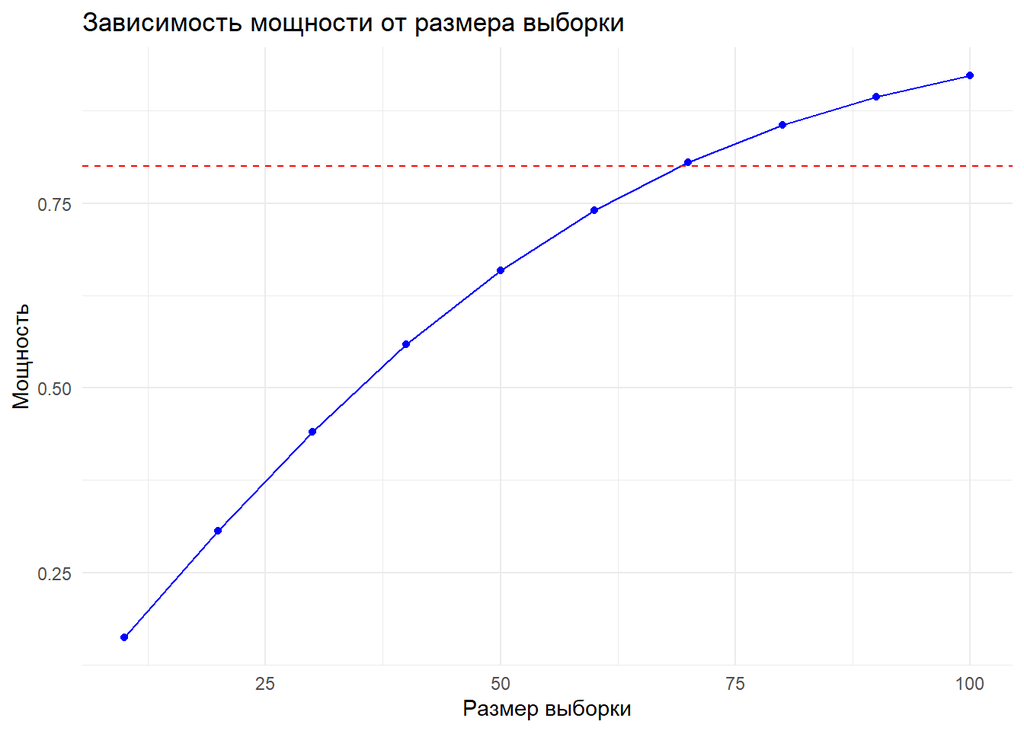

```r
mu_0 <- 5.9
sample_mean <- mean(happiness$happiness_score)
sample_sd <- sd(happiness$happiness_score)
delta <- abs(sample_mean - mu_0)
effect_size <- delta / sample_sd


n_values <- seq(10, 100, by = 10)
power_values <- sapply(n_values, function(n) {
  pwr.t.test(n = n, d = effect_size, sig.level = 0.05, type = "one.sample", alternative = "two.sided")$power
})

plot_data <- data.frame(
  n_values = n_values,
  power_values = power_values
)

ggplot(plot_data, aes(x = n_values, y = power_values)) +
  geom_line(color = "blue") +
  geom_point(color = "blue") +
  geom_hline(yintercept = 0.8, color = "red", linetype = "dashed") +
  labs(
    title = "Зависимость мощности от размера выборки",
    x = "Размер выборки",
    y = "Мощность"
  ) +
  theme_minimal()
```

Видим, что для достижения мощности 0.8 при уровне значимости 0.05 размер выборки должен быть около 70.

### 2. Двухвыборочный критерий Стьюдента.

Сравним математические ожидания уровня счастья в странах Европы и Азии.

```r
europe_table <- happiness[happiness$region %in% c("Western Europe", "Central and Eastern Europe", "Commonwealth of Independent States"), ]
asia_table <- happiness[happiness$region %in% c("East Asia", "Southeast Asia", "South Asia"), ]

europe_mean <- mean(europe_table$happiness_score)
asia_mean <- mean(asia_table$happiness_score)

cat("Среднее для Европы:", europe_mean, "\n")
```

```
## Среднее для Европы: 6.25116
```

```r
cat("Среднее для Азии:", asia_mean, "\n")
```

```
## Среднее для Азии: 5.210136
```

#### 1. Двухсторонний критерий Стьюдента

```r
t.test(europe_table$happiness_score, asia_table$happiness_score, alternative = "two.sided", conf.level = 0.9)
```

```
##
##  Welch Two Sample t-test
##
## data:  europe_table$happiness_score and asia_table$happiness_score
## t = 4.7073, df = 37.299, p-value = 3.418e-05
## alternative hypothesis: true difference in means is not equal to 0
## 90 percent confidence interval:
##  0.6679977 1.4140496
## sample estimates:
## mean of x mean of y
##  6.251160  5.210136
```

```r
t.test(europe_table$happiness_score, asia_table$happiness_score, alternative = "two.sided", conf.level = 0.95)
```

```
##
##  Welch Two Sample t-test
##
## data:  europe_table$happiness_score and asia_table$happiness_score
## t = 4.7073, df = 37.299, p-value = 3.418e-05
## alternative hypothesis: true difference in means is not equal to 0
## 95 percent confidence interval:
##  0.593050 1.488997
## sample estimates:
## mean of x mean of y
##  6.251160  5.210136
```

```r
t.test(europe_table$happiness_score, asia_table$happiness_score, alternative = "two.sided", conf.level = 0.99)
```

```
##
##  Welch Two Sample t-test
##
## data:  europe_table$happiness_score and asia_table$happiness_score
## t = 4.7073, df = 37.299, p-value = 3.418e-05
## alternative hypothesis: true difference in means is not equal to 0
## 99 percent confidence interval:
##  0.4407676 1.6412797
## sample estimates:
## mean of x mean of y
##  6.251160  5.210136
```

#### 2.1. Односторонний критерий Стьюдента. Greater.

```r
t.test(europe_table$happiness_score, asia_table$happiness_score, alternative = "greater", conf.level = 0.9)
```

```
##
##  Welch Two Sample t-test
##
## data:  europe_table$happiness_score and asia_table$happiness_score
## t = 4.7073, df = 37.299, p-value = 1.709e-05
## alternative hypothesis: true difference in means is greater than 0
## 90 percent confidence interval:
##  0.7524956       Inf
## sample estimates:
## mean of x mean of y
##  6.251160  5.210136
```

```r
t.test(europe_table$happiness_score, asia_table$happiness_score, alternative = "greater", conf.level = 0.95)
```

```
##
##  Welch Two Sample t-test
##
## data:  europe_table$happiness_score and asia_table$happiness_score
## t = 4.7073, df = 37.299, p-value = 1.709e-05
## alternative hypothesis: true difference in means is greater than 0
## 95 percent confidence interval:
##  0.6679977       Inf
## sample estimates:
## mean of x mean of y
##  6.251160  5.210136
```

```r
t.test(europe_table$happiness_score, asia_table$happiness_score, alternative = "greater", conf.level = 0.99)
```

```
##
##  Welch Two Sample t-test
##
## data:  europe_table$happiness_score and asia_table$happiness_score
## t = 4.7073, df = 37.299, p-value = 1.709e-05
## alternative hypothesis: true difference in means is greater than 0
## 99 percent confidence interval:
##  0.5035004       Inf
## sample estimates:
## mean of x mean of y
##  6.251160  5.210136
```

#### 2.2. Односторонний критерий Стьюдента. Less.

```r
t.test(europe_table$happiness_score, asia_table$happiness_score, alternative = "less", conf.level = 0.9)
```

```
##
##  Welch Two Sample t-test
##
## data:  europe_table$happiness_score and asia_table$happiness_score
## t = 4.7073, df = 37.299, p-value = 1
## alternative hypothesis: true difference in means is less than 0
## 90 percent confidence interval:
##      -Inf 1.329552
## sample estimates:
## mean of x mean of y
##  6.251160  5.210136
```

```r
t.test(europe_table$happiness_score, asia_table$happiness_score, alternative = "less", conf.level = 0.95)
```

```
##
##  Welch Two Sample t-test
##
## data:  europe_table$happiness_score and asia_table$happiness_score
## t = 4.7073, df = 37.299, p-value = 1
## alternative hypothesis: true difference in means is less than 0
## 95 percent confidence interval:
##     -Inf 1.41405
## sample estimates:
## mean of x mean of y
##  6.251160  5.210136
```

```r
t.test(europe_table$happiness_score, asia_table$happiness_score, alternative = "less", conf.level = 0.99)
```

```
##
##  Welch Two Sample t-test
##
## data:  europe_table$happiness_score and asia_table$happiness_score
## t = 4.7073, df = 37.299, p-value = 1
## alternative hypothesis: true difference in means is less than 0
## 99 percent confidence interval:
##      -Inf 1.578547
## sample estimates:
## mean of x mean of y
##  6.251160  5.210136
```

#### 3. Оценка мощности критерия при заданном объёме и оценка объёма выборки при заданной мощности

Посмотрим, какую мощность имеет критерий при тестировании нашей основной выборки.

```r
n1 <- length(europe_table$happiness_score)
n2 <- length(asia_table$happiness_score)
s1 <- sd(europe_table$happiness_score)
s2 <- sd(asia_table$happiness_score)
delta <- abs(mean(europe_table$happiness_score) - mean(asia_table$happiness_score))
sd <- sqrt(((n1 - 1) * s1^2 + (n2 - 1) * s2^2) / (n1 + n2 - 2)) # объединенное стандартное отклонение
effect_size <- delta / sd
power_result <- pwr.t2n.test(
  n1 = n1,
  n2 = n2,
  d = effect_size,
  sig.level = 0.05,
  alternative = "two.sided"
)

power_result
```

```
##
##      t test power calculation
##
##              n1 = 50
##              n2 = 22
##               d = 1.245067
##       sig.level = 0.05
##           power = 0.9977363
##     alternative = two.sided
```

### b. Ранговый критерий Уилкоксона-Манна-Уитни

Сравним социальную поддержку в странах Европы (Western Europe, Central and Eastern Europe) и в странах Африки (Middle East and North Africa, Sub-Saharan Africa)

```r
europe <- happiness$social_support[happiness$region %in% c("Western Europe", "Central and Eastern Europe")]
africa <- happiness$social_support[happiness$region %in% c("Middle East and North Africa", "Sub-Saharan Africa")]

cat("Mean for Europe:", mean(europe, na.rm = TRUE), "\n")
```

```
## Mean for Europe: 0.9023684
```

```r
cat("Mean for Africa:", mean(africa, na.rm = TRUE), "\n")
```

```
## Mean for Africa: 0.7291132
```

```r
test_two_sided <- wilcox.test(africa, europe, alternative = "two.sided")
test_greater <- wilcox.test(africa, europe, alternative = "greater")
test_less <- wilcox.test(africa, europe, alternative = "less")

# Вывод результатов
cat("EX = EY (two-sided):\t", test_two_sided$statistic, test_two_sided$p.value, "\n")
```

```
## EX = EY (two-sided):  138 2.750144e-12
```

```r
cat("EX > EY (greater):\t", test_greater$statisitc, test_greater$p.value, "\n")
```

```
## EX > EY (greater):    1
```

```r
cat("EX < EY (less):\t\t", test_less$statistic, test_less$p.value, "\n")
```

```
## EX < EY (less):       138 1.375072e-12
```

### c. Проверка гипотез об однородности дисперсий

#### 1. Критерий Фишера

```r
light_exposure_std <- sd(sleep$LightExposureHours, na.rm = TRUE)
movement_std <- sd(sleep$MovementDuringSleep, na.rm = TRUE)

cat("LightExposureHours std:", light_exposure_std, "\n")
```

```
## LightExposureHours std: 2.023371
```

```r
cat("MovementDuringSleep std:", movement_std, "\n")
```

```
## MovementDuringSleep std: 0.9835891
```

```r
fisher_test <- function(x, y, alternative) {
  test <- var.test(x, y, alternative = alternative)
  return(test$p.value)
}

cat("two-sided (DX != DY): ", fisher_test(sleep$MovementDuringSleep, sleep$LightExposureHours, alternative = "two.sided"), "\n")
```

```
## two-sided (DX != DY):  2.27423e-106
```

```r
cat("greater (DX > DY): ", fisher_test(sleep$MovementDuringSleep, sleep$LightExposureHours, alternative = "greater"), "\n")
```

```
## greater (DX > DY):  1
```

```r
cat("less (DX < DY): ", fisher_test(sleep$MovementDuringSleep, sleep$LightExposureHours, alternative = "less"), "\n")
```

```
## less (DX < DY):  1.137115e-106
```

#### 2. Критерий Левене

```r
western <- happiness$gdp[happiness$region == "Western Europe"]
central_eastern <- happiness$gdp[happiness$region == "Central and Eastern Europe"]

western_std <- var(western, na.rm = TRUE)
central_eastern_std <- var(central_eastern, na.rm = TRUE)

cat("Variation for Western Europe:", western_std, "\n")
```

```
## Variation for Western Europe: 0.09305931
```

```r
cat("Variation for Central and Eastern Europe:", central_eastern_std, "\n")
```

```
## Variation for Central and Eastern Europe: 0.1569663
```

```r
leveneTest(c(western, central_eastern),
           group = factor(c(rep("Western Europe", length(western)),
                            rep("Central and Eastern Europe", length(central_eastern)))),
           center = "median")
```

```
## Levene's Test for Homogeneity of Variance (center = "median")
##       Df F value Pr(>F)
## group  1  1.4847  0.231
##       36
```

#### 3. Критерий Барлетта

```r
bartlett.test(list(sleep$MovementDuringSleep, sleep$LightExposureHours))
```

```
##
##  Bartlett test of homogeneity of variances
##
## data:  list(sleep$MovementDuringSleep, sleep$LightExposureHours)
## Bartlett's K-squared = 479.87, df = 1, p-value < 2.2e-16
```

#### 4. Критерий Флингера-Киллина

```r
fligner.test(
  x = c(western, central_eastern),
  g = factor(c(rep("Western Europe", length(western)), rep("Central and Eastern Europe", length(central_eastern))))
)
```

```
##
##  Fligner-Killeen test of homogeneity of variances
##
## data:  c(western, central_eastern) and factor(c(rep("Western Europe", length(western)), rep("Central and Eastern Europe", length(central_eastern))))
## Fligner-Killeen:med chi-squared = 1.103, df = 1, p-value = 0.2936
```

## 9. Исследовать корреляционные взаимосвязи в данных с помощью коэффициентов корреляции Пирсона, Спирмена и Кендалла.

### 1. Корреляция Пирсона

Для вычисления коэффициентов корреляции Пирсона необходимы две нормально распределенных выборки.

```r
shapiro.test(sleep$LightExposureHours)
```

```
##
##  Shapiro-Wilk normality test
##
## data:  sleep$LightExposureHours
## W = 0.99921, p-value = 0.9574
```

```r
shapiro.test(sleep$MovementDuringSleep)
```

```
##
##  Shapiro-Wilk normality test
##
## data:  sleep$MovementDuringSleep
## W = 0.99874, p-value = 0.7173
```

Эти выборки действительно распределены нормально.

```r
cor.test(sleep$LightExposureHours, sleep$MovementDuringSleep, method = "pearson")
```

```
##
##  Pearson's product-moment correlation
##
## data:  sleep$LightExposureHours and sleep$MovementDuringSleep
## t = 0.055217, df = 998, p-value = 0.956
## alternative hypothesis: true correlation is not equal to 0
## 95 percent confidence interval:
##  -0.06025175  0.06373404
## sample estimates:
##         cor
## 0.001747861
```

`p-value > 0.05`, это означает, что нет статистически значимой линейной зависимости между переменными.

### 2. Корреляция Спирмена

Для ненормально распределенных переменных, а также при наличии нелинейной связи между переменными следует использовать непараметрический коэффициент корреляции Спирмена.

```r
cor.test(happiness$gdp, happiness$happiness_score, method = "spearman")
```

```
##
##  Spearman's rank correlation rho
##
## data:  happiness$gdp and happiness$happiness_score
## S = 105074, p-value < 2.2e-16
## alternative hypothesis: true rho is not equal to 0
## sample estimates:
##       rho
## 0.8094072
```

Между переменными существует сильная и значимая положительная монотонная связь. Значение коэффициента Спирмена говорит о том, что с увеличением одной переменной другая также увеличивается, и эта связь достаточно надежна.

```r
cor.test(happiness$gdp, happiness$corruption_perceptions, method = "spearman")
```

```
##
##  Spearman's rank correlation rho
##
## data:  happiness$gdp and happiness$corruption_perceptions
## S = 703968, p-value = 0.0006287
## alternative hypothesis: true rho is not equal to 0
## sample estimates:
##        rho
## -0.2769237
```

### 3. Корреляция Кендалла

```r
cor.test(happiness$gdp, happiness$happiness_score, method = "kendall")
```

```
##
##  Kendall's rank correlation tau
##
## data:  happiness$gdp and happiness$happiness_score
## z = 11.156, p-value < 2.2e-16
## alternative hypothesis: true tau is not equal to 0
## sample estimates:
##       tau
## 0.6165359
```

Между `gdp` и `happiness_score` существует сильная и значимая положительная монотонная связь.

```r
cor.test(happiness$gdp, happiness$corruption_perceptions, method = "kendall")
```

```
##
##  Kendall's rank correlation tau
##
## data:  happiness$gdp and happiness$corruption_perceptions
## z = -3.2089, p-value = 0.001333
## alternative hypothesis: true tau is not equal to 0
## sample estimates:
##        tau
## -0.1774773
```

## 10. Продемонстрировать использование методов хи-квадрат, точного теста Фишера, теста МакНемара, Кохрана-Мантеля-Хензеля.

#### 1. Метод хи-квадрат

Найдем зависимость между уровнем ВВП и регионом проживания.

Разделим показания ВВП на три уровня: низкий (ниже 8.6), средний (от 8.6 до 10.1), высокий (более 10.1).

```r
bins <- c(0, 8.6, 10.1, 100)
labels <- c("low", "mediun", "high")
happiness$gdp_category <- cut(happiness$gdp, breaks = bins, labels = labels, right = FALSE)
```

Для удобства объединим некоторые регионы в бóльшие сущности:

1. `Europe`: `Western Europe` + `Central and Eastern Europe` + `Commonwealth of Independent States`
2. `America`: `North America and ANZ` + `Latin America and Caribbean`
3. `Asia`: `East Asia` + `Southeast Asia` + `South Asia`
4. `Africa`: `Sub-Saharan Africa` + `Middle East and North Africa`

```r
europe_table <- happiness[happiness$region %in% c("Western Europe", "Central and Eastern Europe", "Commonwealth of Independent States"), ]
america_table <- happiness[happiness$region %in% c("North America and ANZ", "Latin America and Caribbean"), ]
asia_table <- happiness[happiness$region %in% c("East Asia", "Southeast Asia", "South Asia"), ]
africa_table <- happiness[happiness$region %in% c("Sub-Saharan Africa", "Middle East and North Africa"), ]


europe_table$region <- "Europe"
africa_table$region <- "Africa"
asia_table$region <- "Asia"
america_table$region <- "America"

set.seed(42)
combined_table <- rbind(europe_table, africa_table, america_table, asia_table)
combined_table <- combined_table[sample(nrow(combined_table)), ]

combined_table <- combined_table[, c("region", "gdp_category")]

contingency_table <- table(combined_table$region, combined_table$gdp_category)

cat("Таблица сопряженности:\n")
```

```
## Таблица сопряженности:
```

```r
print(contingency_table)
```

```
##
##           low mediun high
##   Africa   32     15    6
##   America   1     18    5
##   Asia      6     10    6
##   Europe    2     15   33
```

```r
chi2_result <- chisq.test(contingency_table)
cat("Результаты теста хи-квадрат:\n")
```

```
## Результаты теста хи-квадрат:
```

```r
cat(sprintf("χ²: %.4f, p-значение: %f, степени свободы: %d\n",
            chi2_result$statistic, chi2_result$p.value, chi2_result$parameter))
```

```
## χ²: 71.3370, p-значение: 0.000000, степени свободы: 6
```

```r
cat("\nОжидаемые частоты:\n")
```

```
##
## Ожидаемые частоты:
```

```r
print(chi2_result$expected)
```

```
##
##                 low    mediun      high
##   Africa  14.583893 20.630872 17.785235
##   America  6.604027  9.342282  8.053691
##   Asia     6.053691  8.563758  7.382550
##   Europe  13.758389 19.463087 16.778523
```

Значение p-value < 0.05, значит между регионом и уровнем ВВП существует статистически значимая зависимость.

#### 2. Точный тест Фишера

```r
europe_table <- happiness[happiness$region %in% c("Western Europe", "Central and Eastern Europe"), ]
africa_table <- happiness[happiness$region %in% c("Middle East and North Africa", "Sub-Saharan Africa"), ]

europe_table$region <- "Europe"
africa_table$region <- "Africa"

set.seed(42)
combined_table <- rbind(europe_table, africa_table)
combined_table <- combined_table[sample(nrow(combined_table)), ]

combined_table <- combined_table[, c("region", "happiness_score")]
combined_table$happiness_category <- ifelse(combined_table$happiness_score > 6, "happy", "unhappy")

contingency_table <- table(combined_table$region, combined_table$happiness_category)

cat("Таблица сопряженности:\n")
```

```
## Таблица сопряженности:
```

```r
print(contingency_table)
```

```
##
##          happy unhappy
##   Africa     6      47
##   Europe    28      10
```

```r
fisher_result <- fisher.test(contingency_table)
```

```r
fisher_result <- fisher.test(contingency_table)

cat("Отношение шансов:", fisher_result$estimate, "\n")
```

```
## Отношение шансов: 0.04788731
```

```r
cat("p-значение:", fisher_result$p.value, "\n")
```

```
## p-значение: 1.694171e-09
```

Значение p-value < 0.05, значит между регионом и уровнем счастья существует статистически значимая зависимость.

#### 3. Тест МакНемара

Я нашел данные об уровне счастья за 2023 год. Сравним изменения. Пусть страна является счастливой, если `happiness_score > 6`.

```r
happiness2023 <- read.csv("../happiness2023.csv")

colnames(happiness2023)[colnames(happiness2023) == "Ladder.score"] <- "happiness_score"
colnames(happiness2023)[colnames(happiness2023) == "Regional.indicator"] <- "region"
colnames(happiness2023)[colnames(happiness2023) == "Standard.error.of.ladder.score"] <- "std_happiness_score"
colnames(happiness2023)[colnames(happiness2023) == "Logged.GDP.per.capita"] <- "gdp"
colnames(happiness2023)[colnames(happiness2023) == "Social.support"] <- "social_support"
colnames(happiness2023)[colnames(happiness2023) == "Freedom.to.make.life.choices"] <- "freedom"
colnames(happiness2023)[colnames(happiness2023) == "Generosity"] <- "generosity"
colnames(happiness2023)[colnames(happiness2023) == "Perceptions.of.corruption"] <- "corruption_perceptions"
colnames(happiness2023)[colnames(happiness2023) == "Healthy.life.expectancy"] <- "life_expectancy"
colnames(happiness2023)[colnames(happiness2023) == "Country.name"] <- "Country name"

happiness2023 <- happiness2023[, 1:12]

happiness2023 <- happiness2023[, !(colnames(happiness2023) %in% c("std_happiness_score", "upperwhisker", "lowerwhisker", "Ladder.score.in.Dystopia"))]

head(happiness2023, 3)
```

```
##   Country name happiness_score    gdp social_support life_expectancy freedom
## 1      Finland           7.804 10.792          0.969           71.15   0.961
## 2      Denmark           7.586 10.962          0.954           71.25   0.934
## 3      Iceland           7.530 10.896          0.983           72.05   0.936
##   generosity corruption_perceptions
## 1     -0.019                  0.182
## 2      0.134                  0.196
## 3      0.211                  0.668
```

```r
happiness$happiness_category <- ifelse(happiness$happiness_score > 6, "happy", "unhappy")
happiness2023$happiness_category <- ifelse(happiness2023$happiness_score > 6, "happy", "unhappy")

sub_happiness <- happiness[, c("Country name", "happiness_category")]
sub_happiness2023 <- happiness2023[, c("Country name", "happiness_category")]

sub_happiness$year <- 2021
sub_happiness2023$year <- 2023

combined_data <- merge(
  sub_happiness[, c("Country name", "happiness_category")],
  sub_happiness2023[, c("Country name", "happiness_category")],
  by = "Country name",
  suffixes = c("_2021", "_2023")
)

head(combined_data)
```

```
##   Country name happiness_category_2021 happiness_category_2023
## 1  Afghanistan                 unhappy                 unhappy
## 2      Albania                 unhappy                 unhappy
## 3      Algeria                 unhappy                 unhappy
## 4    Argentina                 unhappy                   happy
## 5      Armenia                 unhappy                 unhappy
## 6    Australia                   happy                   happy
```

```r
contingency_table <- table(
  `2021` = combined_data$happiness_category_2021,
  `2023` = combined_data$happiness_category_2023
)

cat("Таблица сопряженности 2×2:\n")
```

```
## Таблица сопряженности 2×2:
```

```r
print(contingency_table)
```

```
##          2023
## 2021      happy unhappy
##   happy      47       3
##   unhappy     7      76
```

```r
mcnemar_result <- mcnemar.test(contingency_table)
cat(sprintf("Статистика: %f, p-значение: %f\n", mcnemar_result$statistic, mcnemar_result$p.value))
```

```
## Статистика: 0.900000, p-значение: 0.342782
```

`p-value > 0.05`, что свидетельствует о отсутствии статистически значимых изменениий между уровнем счастья в мире в 2021 и 2023 годах.

#### 4. Тест Кохрана-Мантеля-Хензеля

```r
happiness$social_support_category <- ifelse(happiness$social_support > 0.77, "high", "low")
happiness$happiness_category <- ifelse(happiness$happiness_score > 6, "happy", "unhappy")

europe_table <- subset(happiness, region %in% c("Western Europe", "Central and Eastern Europe", "Commonwealth of Independent States"))
america_table <- subset(happiness, region %in% c("North America and ANZ", "Latin America and Caribbean"))
asia_table <- subset(happiness, region %in% c("East Asia", "Southeast Asia", "South Asia"))
africa_table <- subset(happiness, region %in% c("Sub-Saharan Africa", "Middle East and North Africa"))

europe_table$region <- "Europe"
africa_table$region <- "Africa"
asia_table$region <- "Asia"
america_table$region <- "America"


combined_table <- rbind(europe_table, africa_table, america_table, asia_table)


set.seed(42)
combined_table <- combined_table[sample(nrow(combined_table)), ]


combined_table <- combined_table[, c("region", "happiness_category", "social_support_category")]

head(combined_table)
```

```
##      region happiness_category social_support_category
## 108  Europe            unhappy                     low
## 99   Africa            unhappy                     low
## 115  Africa            unhappy                     low
## 126    Asia            unhappy                    high
## 66  America            unhappy                    high
## 149    Asia            unhappy                     low
```

```r
regions <- unique(combined_table$region)
stratified_data <- list()

for (region in regions) {
  subset <- combined_table[combined_table$region == region, ]
  contingency_table <- table(subset$happiness_category, subset$social_support_category)
  stratified_data[[region]] <- contingency_table
}
stratified_data
```

```
## $Europe
##
##           high low
##   happy     30   0
##   unhappy   18   2
##
## $Africa
##
##           high low
##   happy      6   0
##   unhappy   13  34
##
## $Asia
##
##           high low
##   happy      2   0
##   unhappy   14   6
##
## $America
##
##           high low
##   happy     13   1
##   unhappy    9   1
```

```r
combined_array <- array(NA, dim = c(2, 2, length(stratified_data)))
for (i in seq_along(stratified_data)) {
  combined_array[,,i] <- stratified_data[[i]]
}
cmh_result <- mantelhaen.test(combined_array)
print(cmh_result)
```

```
##
##  Mantel-Haenszel chi-squared test with continuity correction
##
## data:  combined_array
## Mantel-Haenszel X-squared = 10.812, df = 1, p-value = 0.001009
## alternative hypothesis: true common odds ratio is not equal to 1
## 95 percent confidence interval:
##    2.130018 125.704286
## sample estimates:
## common odds ratio
##          16.36314
```

## 11. Проверить наличие мультиколлинеарности в данных с помощью корреляционной матрицы и фактора инфляции дисперсии.

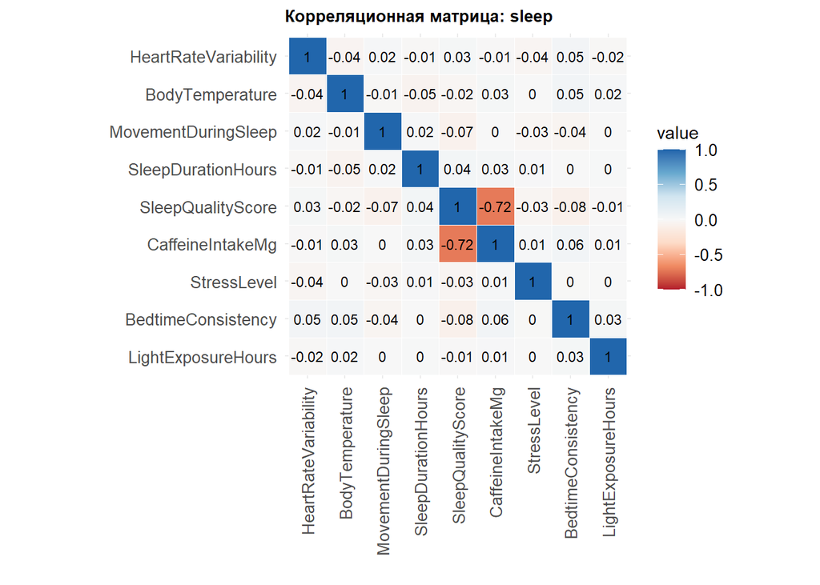

```r
numeric_vars <- sapply(sleep, is.numeric)
sleep_numeric <- sleep[, numeric_vars]

custom_order <- c(
  "HeartRateVariability", "BodyTemperature", "MovementDuringSleep",
  "SleepDurationHours", "SleepQualityScore", "CaffeineIntakeMg",
  "StressLevel", "BedtimeConsistency", "LightExposureHours"
)

corr <- cor(sleep_numeric, use = "complete.obs")

corr <- corr[custom_order, rev(custom_order)]

corr_melted <- melt(corr)

ggplot(data = corr_melted, aes(x = Var1, y = Var2, fill = value)) +
  geom_tile(color = "white") +
  scale_fill_distiller(palette = "RdBu", limits = c(-1, 1), direction = 1) +
  geom_text(aes(label = round(value, 2)), size = 3) +
  theme_minimal() +
  theme(axis.text.x = element_text(size = 10, angle = 90, hjust = 1, vjust = 0.5),
        axis.text.y = element_text(size = 10),
        legend.text = element_text(size = 10),
        plot.title = element_text(size = 10, face = "bold")) +
  labs(title = "Корреляционная матрица: sleep", x = "", y = "") +
  coord_fixed()
```

Видна четкая зависимость между оценкой качества сна и количеством принятого кофеина: чем больше человек принял кофеина (например, выпил много кофе), тем хуже он спит.

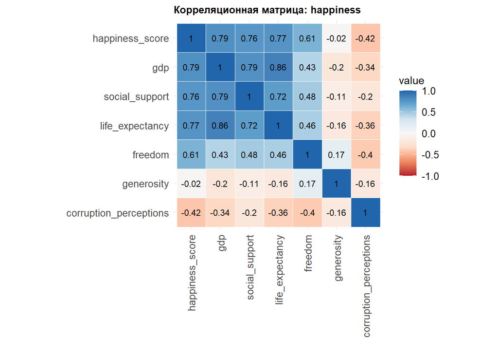

```r
happiness_numeric <- happiness[sapply(happiness, is.numeric)]
corr <- cor(happiness_numeric, use = "complete.obs")

custom_order <- c(
  "happiness_score",
  "gdp",
  "social_support",
  "life_expectancy",
  "freedom",
  "generosity",
  "corruption_perceptions"
)

corr <- corr[custom_order, rev(custom_order)]

corr_melted <- melt(corr)

ggplot(data = corr_melted, aes(x = Var1, y = Var2, fill = value)) +
  geom_tile(color = "white") +
  scale_fill_distiller(palette = "RdBu", limits = c(-1, 1), direction = 1) +
  geom_text(aes(label = round(value, 2)), size = 3) +
  theme_minimal() +
  theme(axis.text.x = element_text(size = 10, angle = 90, hjust = 1, vjust = 0.5),
        axis.text.y = element_text(size = 10),
        legend.text = element_text(size = 10),
        plot.title = element_text(size = 10, face = "bold")) +
  labs(title = "Корреляционная матрица: happiness", x = "", y = "") +
  coord_fixed()
```

Как мы можем заметить, на уровень счастья в стране влияют высокий показатель ВВП (т.е. развитая экономика), высокая социальная поддержка (пенсии, стипендии, хорошее медобслуживание и прочее), уровень свободы, однако очень много людей беспокоит уровень коррупции, что снижает уровень счастья.

```r
selected_features <- c(
  "HeartRateVariability",
  "BodyTemperature",
  "MovementDuringSleep",
  "SleepDurationHours",
  "SleepQualityScore",
  "CaffeineIntakeMg",
  "StressLevel",
  "BedtimeConsistency",
  "LightExposureHours"
)
sleep_selected <- sleep[, selected_features]
sleep_selected$const <- 1
model <- lm(const ~ ., data = sleep_selected)
VIFs <- vif(model)
VIF_table <- data.frame(
  Variable = names(VIFs),
  VIF = as.numeric(VIFs)
)
print(VIF_table)
```

```
##               Variable      VIF
## 1 HeartRateVariability 1.007952
## 2      BodyTemperature 1.008979
## 3  MovementDuringSleep 1.013596
## 4   SleepDurationHours 1.015059
## 5    SleepQualityScore 2.125253
## 6     CaffeineIntakeMg 2.103486
## 7          StressLevel 1.003903
## 8   BedtimeConsistency 1.014817
## 9   LightExposureHours 1.001373
```

Высокие значения VIF указывают на потенциальные проблемы с мультиколлинеарностью. Как правило, значение VIF выше 5 требует внимания, а выше 10 — серьезного рассмотрения изменений в модели. У нас все в порядке.

```r
library(car)
selected_features <- c(
  "happiness_score",
  "gdp",
  "social_support",
  "life_expectancy",
  "freedom",
  "generosity",
  "corruption_perceptions"
)
happiness_selected <- happiness[, selected_features]
happiness_selected$const <- 1
model <- lm(const ~ ., data = happiness_selected)
VIFs <- vif(model)
VIF_table <- data.frame(
  Variable = names(VIFs),
  VIF = as.numeric(VIFs)
)

print(VIF_table)
```

```
##                 Variable      VIF
## 1        happiness_score 4.095795
## 2                    gdp 5.477390
## 3         social_support 3.259623
## 4        life_expectancy 4.248569
## 5                freedom 1.770176
## 6             generosity 1.191685
## 7 corruption_perceptions 1.408890
```

```r
selected_features <- c(
  "happiness_score",
  "social_support",
  "life_expectancy",
  "freedom",
  "generosity",
  "corruption_perceptions"
)
happiness_selected <- happiness[, selected_features]
happiness_selected$const <- 1
model <- lm(const ~ ., data = happiness_selected)
VIFs <- vif(model)
VIF_table <- data.frame(
  Variable = names(VIFs),
  VIF = as.numeric(VIFs)
)

print(VIF_table)
```

```
##                 Variable      VIF
## 1        happiness_score 3.817253
## 2         social_support 2.837053
## 3        life_expectancy 2.963900
## 4                freedom 1.742486
## 5             generosity 1.154653
## 6 corruption_perceptions 1.391416
```

## 12. Исследовать зависимости в данных с помощью дисперсионного анализа

### 1. One-Way ANOVA

Вспомним, что в датасете `happiness` есть нормально распределенная выборка `happiness_score` (это так, поскольку тест Шапиро-Уилка выдает `p-value > 0.05`). Предполагаем, что результаты тестирования стран на уровень счастья независимые.

```r
shapiro.test(happiness$happiness_score)
```

```
##
##  Shapiro-Wilk normality test
##
## data:  happiness$happiness_score
## W = 0.99125, p-value = 0.4893
```

Для определения гомогенности дисперсий вначале обратимся к `stripchart` уровня счастья в зависимости от региона.

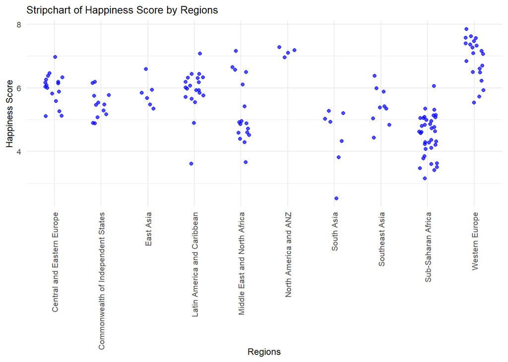

```r
ggplot(happiness, aes(x = region, y = happiness_score)) +
  geom_jitter(color = "blue", width = 0.2, alpha = 0.7) +
  theme_minimal() +
  theme(
    axis.text.x = element_text(size = 8, angle = 90, vjust = 0.5, hjust = 1),
    axis.text.y = element_text(size = 8),
    plot.title = element_text(size = 10),
    axis.title.x = element_text(size = 9),
    axis.title.y = element_text(size = 9)
  ) +
  labs(
    title = "Stripchart of Happiness Score by Regions",
    x = "Regions",
    y = "Happiness Score"
  )
```

Заметим, что регионы `Latin America and Caribbean`, `Sub-Saharan Africa`, `Middle East and North Africa` сильно выделяются на фоне других по дисперсии. Проведем тест Левене для оставшихся них.

```r
subset_data <- happiness[happiness$region %in% c("Middle East and North Africa",
                                                 "Latin America and Caribbean",
                                                 "Sub-Saharan Africa"), ]
subset_data$region <- as.factor(subset_data$region)
leveneTest(happiness_score ~ as.factor(region), data = subset_data, center = median)
```

```
## Levene's Test for Homogeneity of Variance (center = median)
##       Df F value Pr(>F)
## group  2   1.728 0.1851
##       70
```

`p-value > 0.05`, поэтому можем принять гипотезу о равенстве дисперсий. One-Way ANOVA применим.

```r
anova_result <- aov(happiness_score ~ region, data = subset_data)
summary(anova_result)
```

```
##             Df Sum Sq Mean Sq F value   Pr(>F)
## region       2  26.32  13.162   22.96 2.15e-08 ***
## Residuals   70  40.12   0.573
## ---
## Signif. codes:  0 '***' 0.001 '**' 0.01 '*' 0.05 '.' 0.1 ' ' 1
```

Мы не можем принять гипотезу о равенстве средних, значит, регион проживания действительно влияет на уровень счастья.

### 2. Two-Way ANOVA

Теперь исследуем влияние нескольких факторов на уровень счастья. Создадим новую факторную переменную `freedom_level`, основанную на `freedom`.

```r
happiness$freedom_level <- cut(
  happiness$freedom,
  breaks = c(-1, 0.7, 0.85, 1),
  labels = c("Low", "Medium", "High"),
  right = TRUE # включить правую границу
)

sub_happiness <- happiness[happiness$region %in% c("Middle East and North Africa",
                                                   "Latin America and Caribbean",
                                                   "Sub-Saharan Africa"), ]
head(sub_happiness)
```

```
##            Country name                       region happiness_score    gdp
## 12               Israel Middle East and North Africa           7.157 10.575
## 16           Costa Rica  Latin America and Caribbean           7.069  9.880
## 22              Bahrain Middle East and North Africa           6.647 10.669
## 25 United Arab Emirates Middle East and North Africa           6.561 11.085
## 26         Saudi Arabia Middle East and North Africa           6.494 10.743
## 30            Guatemala  Latin America and Caribbean           6.435  9.053
##    social_support life_expectancy freedom generosity corruption_perceptions
## 12          0.939          73.503   0.800      0.031                  0.753
## 16          0.891          71.400   0.934     -0.126                  0.809
## 22          0.862          69.495   0.925      0.089                  0.722
## 25          0.844          67.333   0.932      0.074                  0.589
## 26          0.891          66.603   0.877     -0.149                  0.684
## 30          0.813          64.958   0.906     -0.038                  0.775
##    gdp_category happiness_category social_support_category freedom_level
## 12         high              happy                    high        Medium
## 16       mediun              happy                    high          High
## 22         high              happy                    high          High
## 25         high              happy                    high          High
## 26         high              happy                    high          High
## 30       mediun              happy                    high          High
```

```r
sub_happiness$region <- as.factor(sub_happiness$region)
sub_happiness$freedom_level <- as.factor(sub_happiness$freedom_level)

model <- lm(happiness_score ~ freedom_level * region, data = sub_happiness)
anova_table <- Anova(model, type = 2)
print(anova_table)
```

```
## Anova Table (Type II tests)
##
## Response: happiness_score
##                       Sum Sq Df F value    Pr(>F)
## freedom_level         8.8300  2 11.5147 5.351e-05 ***
## region               11.5854  2 15.1078 4.225e-06 ***
## freedom_level:region  6.7551  4  4.4045  0.003301 **
## Residuals            24.5391 64
## ---
## Signif. codes:  0 '***' 0.001 '**' 0.01 '*' 0.05 '.' 0.1 ' ' 1
```

Вышеперечисленные факторы и их сочетания влияют на уровень счастья.

## 13. Подогнать регрессионные модели (в том числе, нелинейные) к данным, а также оценить качество подобной аппроксимации.

#### 1. Линейная регрессия на объединенных данных за 2021 и 2023 годы

```r
head(happiness)
```

```
##   Country name         region happiness_score    gdp social_support
## 1      Finland Western Europe           7.842 10.775          0.954
## 2      Denmark Western Europe           7.620 10.933          0.954
## 3  Switzerland Western Europe           7.571 11.117          0.942
## 4      Iceland Western Europe           7.554 10.878          0.983
## 5  Netherlands Western Europe           7.464 10.932          0.942
## 6       Norway Western Europe           7.392 11.053          0.954
##   life_expectancy freedom generosity corruption_perceptions gdp_category
## 1            72.0   0.949     -0.098                  0.186         high
## 2            72.7   0.946      0.030                  0.179         high
## 3            74.4   0.919      0.025                  0.292         high
## 4            73.0   0.955      0.160                  0.673         high
## 5            72.4   0.913      0.175                  0.338         high
## 6            73.3   0.960      0.093                  0.270         high
##   happiness_category social_support_category freedom_level
## 1              happy                    high          High
## 2              happy                    high          High
## 3              happy                    high          High
## 4              happy                    high          High
## 5              happy                    high          High
## 6              happy                    high          High
```

```r
sub_happiness <- happiness[, c("happiness_score", "gdp", "social_support", "life_expectancy",
                                "freedom", "generosity")]
sub_happiness2023 <- happiness2023[, c("happiness_score", "gdp", "social_support", "life_expectancy",
                                       "freedom", "generosity")]

happiness_combined <- rbind(sub_happiness, sub_happiness2023)
replace_na_with_median <- function(x) {
  if (is.numeric(x)) {
    x[is.na(x)] <- median(x, na.rm = TRUE)
  }
  return(x)
}

happiness_combined <- as.data.frame(lapply(happiness_combined, replace_na_with_median))
head(happiness_combined)
```

```
##   happiness_score    gdp social_support life_expectancy freedom generosity
## 1           7.842 10.775          0.954            72.0   0.949     -0.098
## 2           7.620 10.933          0.954            72.7   0.946      0.030
## 3           7.571 11.117          0.942            74.4   0.919      0.025
## 4           7.554 10.878          0.983            73.0   0.955      0.160
## 5           7.464 10.932          0.942            72.4   0.913      0.175
## 6           7.392 11.053          0.954            73.3   0.960      0.093
```

```r
X <- happiness_combined[, setdiff(names(happiness_combined), "happiness_score")]
y <- happiness_combined$happiness_score
X <- as.matrix(X)
y <- as.numeric(y)
model <- lm(y ~ X)
summary(model)
```

```
##
## Call:
## lm(formula = y ~ X)
##
## Residuals:
##      Min       1Q   Median       3Q      Max
## -1.89897 -0.29059  0.04053  0.36076  1.21185
##
## Coefficients:
##                   Estimate Std. Error t value Pr(>|t|)
## (Intercept)      -3.340927   0.341706  -9.777  < 2e-16 ***
## Xgdp              0.284910   0.054328   5.244 3.10e-07 ***
## Xsocial_support   2.888934   0.416415   6.938 2.77e-11 ***
## Xlife_expectancy  0.029156   0.009464   3.081  0.00227 **
## Xfreedom          2.481325   0.333005   7.451 1.15e-12 ***
## Xgenerosity       0.478440   0.222682   2.149  0.03253 *
## ---
## Signif. codes:  0 '***' 0.001 '**' 0.01 '*' 0.05 '.' 0.1 ' ' 1
##
## Residual standard error: 0.5227 on 280 degrees of freedom
## Multiple R-squared:  0.7798, Adjusted R-squared:  0.7759
## F-statistic: 198.3 on 5 and 280 DF,  p-value: < 2.2e-16
```

```r
pred <- model$fitted.values
mse <- mean((y - pred)^2)
rmse <- sqrt(mse)

cat("MSE: ", mse, "\n")
```

```
## MSE:  0.2674736
```

```r
cat("RMSE: ", rmse, "\n")
```

```
## RMSE:  0.5171785
```

```r
model_1 <- lm(happiness_score ~ gdp, data = happiness_combined)
summary(model_1)
```

```
##
## Call:
## lm(formula = happiness_score ~ gdp, data = happiness_combined)
##
## Residuals:
##     Min      1Q  Median      3Q     Max
## -3.1717 -0.3710  0.0602  0.4463  2.5564
##
## Coefficients:
##             Estimate Std. Error t value Pr(>|t|)
## (Intercept) -1.41491    0.32585  -4.342 1.96e-05 ***
## gdp          0.73629    0.03425  21.498  < 2e-16 ***
## ---
## Signif. codes:  0 '***' 0.001 '**' 0.01 '*' 0.05 '.' 0.1 ' ' 1
##
## Residual standard error: 0.6824 on 284 degrees of freedom
## Multiple R-squared:  0.6194, Adjusted R-squared:  0.618
## F-statistic: 462.1 on 1 and 284 DF,  p-value: < 2.2e-16
```

```r
pred <- model_1$fitted.values
mse <- mean((y - pred)^2)
rmse <- sqrt(mse)

cat("MSE: ", mse, "\n")
```

```
## MSE:  0.4623587
```

```r
cat("RMSE: ", rmse, "\n")
```

```
## RMSE:  0.6799696
```

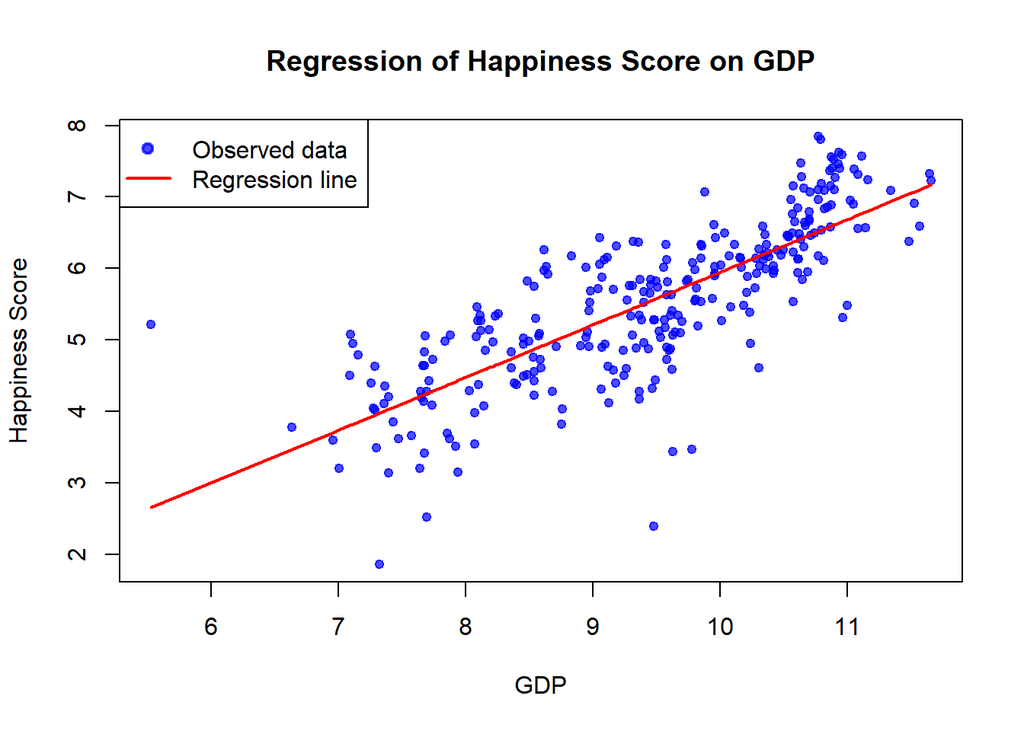

```r
pred <- predict(model_1, newdata = happiness_combined)

plot(happiness_combined$gdp, happiness_combined$happiness_score,
     main = "Regression of Happiness Score on GDP",
     xlab = "GDP", ylab = "Happiness Score",
     pch = 19, col = rgb(0, 0, 1, 0.7), cex = 0.8)  # цвет и размер точек

lines(sort(happiness_combined$gdp),
      sort(pred),
      col = "red", lwd = 2)

legend("topleft", legend = c("Observed data", "Regression line"),
       col = c(rgb(0, 0, 1, 0.7), "red"), pch = c(19, NA), lty = c(NA, 1), lwd = 2)
```

#### 2. Полиномиальная регрессия на объединенных данных за 2021 и 2023 годы

```r
X <- happiness_combined[, setdiff(names(happiness_combined), "happiness_score")]
y <- happiness_combined$happiness_score
degree <- 2
poly_features <- as.data.frame(poly(as.matrix(X), degree = degree, raw = TRUE))
names(poly_features) <- paste0("V", seq_along(names(poly_features)))
poly_features$y <- y
formula <- as.formula(paste("y ~", paste(names(poly_features)[-ncol(poly_features)], collapse = " + ")))
model <- lm(formula, data = poly_features)
summary(model)
```

```
##
## Call:
## lm(formula = formula, data = poly_features)
##
## Residuals:
##      Min       1Q   Median       3Q      Max
## -1.45478 -0.26273  0.07042  0.28547  0.94735
##
## Coefficients:
##               Estimate Std. Error t value Pr(>|t|)
## (Intercept)   9.782049   3.097816   3.158 0.001774 **
## V1            0.621339   0.621390   1.000 0.318262
## V2            0.118114   0.044093   2.679 0.007852 **
## V3          -20.444375   4.722154  -4.329 2.12e-05 ***
## V4           -0.348073   0.718172  -0.485 0.628314
## V5           -7.835072   3.511393  -2.231 0.026496 *
## V6           -0.155564   0.109013  -1.427 0.154753
## V7           -0.027008   0.015933  -1.695 0.091234 .
## V8            0.622520   0.112807   5.518 8.14e-08 ***
## V9           -0.001233   0.001794  -0.687 0.492419
## V10           4.214321   4.270274   0.987 0.324593
## V11          -0.584549   0.650251  -0.899 0.369491
## V12          -0.717301   3.766462  -0.190 0.849107
## V13           0.112118   0.120656   0.929 0.353612
## V14          -2.330294   2.536562  -0.919 0.359097
## V15           6.266056   2.941922   2.130 0.034100 *
## V16           1.078206   0.471967   2.284 0.023133 *
## V17           7.658492   3.279856   2.335 0.020290 *
## V18          -0.272648   0.077412  -3.522 0.000504 ***
## V19          -5.554119   2.727089  -2.037 0.042679 *
## V20          -2.009459   1.074118  -1.871 0.062475 .
## ---
## Signif. codes:  0 '***' 0.001 '**' 0.01 '*' 0.05 '.' 0.1 ' ' 1
##
## Residual standard error: 0.4597 on 265 degrees of freedom
## Multiple R-squared:  0.8388, Adjusted R-squared:  0.8266
## F-statistic: 68.93 on 20 and 265 DF,  p-value: < 2.2e-16
```

```r
pred <- model$fitted.values
mse <- mean((y - pred)^2)
rmse <- sqrt(mse)

cat("MSE: ", mse, "\n")
```

```
## MSE:  0.1958438
```

```r
cat("RMSE: ", rmse, "\n")
```

```
## RMSE:  0.4425424
```

```r
model_poly <- lm(happiness_score ~ gdp + I(gdp^2), data = happiness_combined)
summary(model_poly)
```

```
##
## Call:
## lm(formula = happiness_score ~ gdp + I(gdp^2), data = happiness_combined)
##
## Residuals:
##      Min       1Q   Median       3Q      Max
## -3.02379 -0.37026  0.01518  0.43937  1.44906
##
## Coefficients:
##             Estimate Std. Error t value Pr(>|t|)
## (Intercept)   7.5689     2.1259   3.560 0.000434 ***
## gdp          -1.2518     0.4664  -2.684 0.007705 **
## I(gdp^2)      0.1081     0.0253   4.274 2.63e-05 ***
## ---
## Signif. codes:  0 '***' 0.001 '**' 0.01 '*' 0.05 '.' 0.1 ' ' 1
##
## Residual standard error: 0.6625 on 283 degrees of freedom
## Multiple R-squared:  0.6425, Adjusted R-squared:  0.6399
## F-statistic: 254.3 on 2 and 283 DF,  p-value: < 2.2e-16
```

```r
pred <- model_poly$fitted.values
mse <- mean((y - pred)^2)
rmse <- sqrt(mse)

cat("MSE: ", mse, "\n")
```

```
## MSE:  0.4343301
```

```r
cat("RMSE: ", rmse, "\n")
```

```
## RMSE:  0.6590372
```

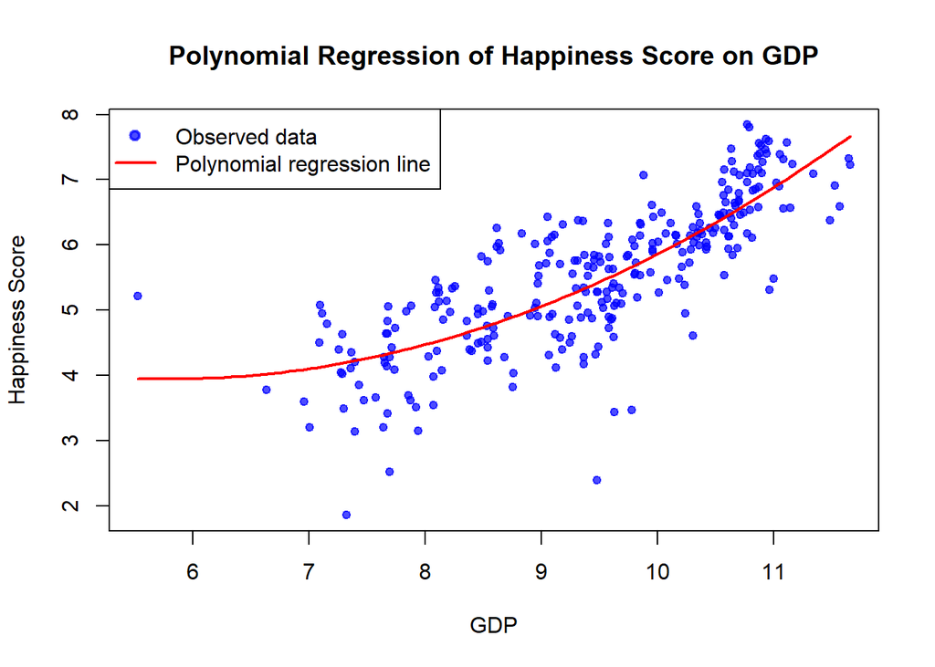

```r
gdp_sorted <- seq(min(happiness_combined$gdp), max(happiness_combined$gdp), length.out = 100)
predicted_happiness <- predict(model_poly, newdata = data.frame(gdp = gdp_sorted))
plot(happiness_combined$gdp, happiness_combined$happiness_score,
     main = "Polynomial Regression of Happiness Score on GDP",
     xlab = "GDP", ylab = "Happiness Score",
     pch = 19, col = rgb(0, 0, 1, 0.7), cex = 0.8)

lines(gdp_sorted, predicted_happiness, col = "red", lwd = 2)
legend("topleft", legend = c("Observed data", "Polynomial regression line"),
       col = c(rgb(0, 0, 1, 0.7), "red"), pch = c(19, NA), lty = c(NA, 1), lwd = 2)
```

#### 3. Логарифмическая регрессия на объединенных данных за 2021 и 2023 годы

```r
X <- happiness_combined[, setdiff(names(happiness_combined), "happiness_score")]
y <- happiness_combined$happiness_score

X_log <- log1p(X)
X_log <- as.matrix(X_log)
y <- as.numeric(y)
model_log <- lm(y ~ X_log)
summary(model_log)
```

```
##
## Call:
## lm(formula = y ~ X_log)
##
## Residuals:
##      Min       1Q   Median       3Q      Max
## -1.86883 -0.29177  0.04295  0.37260  1.24471
##
## Coefficients:
##                      Estimate Std. Error t value Pr(>|t|)
## (Intercept)          -14.8488     1.7533  -8.469 1.42e-15 ***
## X_loggdp               2.7811     0.5378   5.172 4.42e-07 ***
## X_logsocial_support    4.9545     0.7280   6.805 6.12e-11 ***
## X_loglife_expectancy   2.0335     0.5968   3.407 0.000752 ***
## X_logfreedom           4.2328     0.5898   7.177 6.43e-12 ***
## X_loggenerosity        0.6212     0.2359   2.634 0.008914 **
## ---
## Signif. codes:  0 '***' 0.001 '**' 0.01 '*' 0.05 '.' 0.1 ' ' 1
##
## Residual standard error: 0.5326 on 280 degrees of freedom
## Multiple R-squared:  0.7714, Adjusted R-squared:  0.7673
## F-statistic:   189 on 5 and 280 DF,  p-value: < 2.2e-16
```

```r
pred <- model_log$fitted.values
mse <- mean((y - pred)^2)
rmse <- sqrt(mse)

cat("MSE: ", mse, "\n")
```

```
## MSE:  0.2776784
```

```r
cat("RMSE: ", rmse, "\n")
```

```
## RMSE:  0.526952
```

```r
model_log <- lm(happiness_score ~ log(gdp), data = happiness_combined)
summary(model_log)
```

```
##
## Call:
## lm(formula = happiness_score ~ log(gdp), data = happiness_combined)
##
## Residuals:
##     Min      1Q  Median      3Q     Max
## -3.2238 -0.4092  0.0587  0.4422  3.1203
##
## Coefficients:
##             Estimate Std. Error t value Pr(>|t|)
## (Intercept)  -9.0838     0.7146  -12.71   <2e-16 ***
## log(gdp)      6.5361     0.3189   20.49   <2e-16 ***
## ---
## Signif. codes:  0 '***' 0.001 '**' 0.01 '*' 0.05 '.' 0.1 ' ' 1
##
## Residual standard error: 0.7025 on 284 degrees of freedom
## Multiple R-squared:  0.5966, Adjusted R-squared:  0.5951
## F-statistic:   420 on 1 and 284 DF,  p-value: < 2.2e-16
```

```r
pred <- model_log$fitted.values
mse <- mean((y - pred)^2)
rmse <- sqrt(mse)

cat("MSE: ", mse, "\n")
```

```
## MSE:  0.490067
```

```r
cat("RMSE: ", rmse, "\n")
```

```
## RMSE:  0.7000478
```

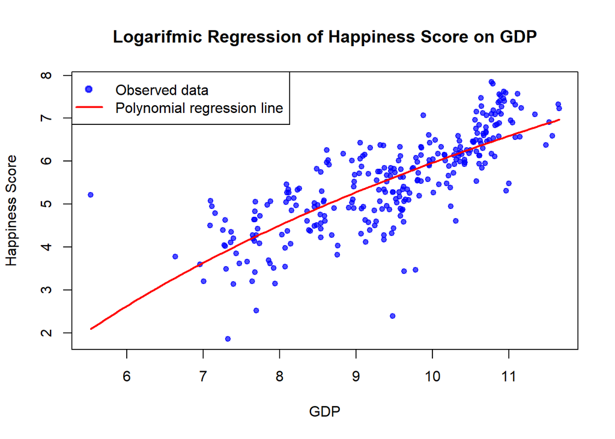

```r
gdp_sorted <- seq(min(happiness_combined$gdp), max(happiness_combined$gdp), length.out = 100)
predicted_happiness <- predict(model_log, newdata = data.frame(gdp = gdp_sorted))
plot(happiness_combined$gdp, happiness_combined$happiness_score,
     main = "Logarifmic Regression of Happiness Score on GDP",
     xlab = "GDP", ylab = "Happiness Score",
     pch = 19, col = rgb(0, 0, 1, 0.7), cex = 0.8)

lines(gdp_sorted, predicted_happiness, col = "red", lwd = 2)
legend("topleft", legend = c("Observed data", "Polynomial regression line"),
       col = c(rgb(0, 0, 1, 0.7), "red"), pch = c(19, NA), lty = c(NA, 1), lwd = 2)
```